# RF_mejor_respuesta

Ainhoa

2024-05-19

```r
packages <- c('tidyverse', 'rpart', 'rpart.plot', 'gtools', 'Rmisc', 'scales', 'viridis', 'caret', 'AMR', 'randomForest', 'fastDummies', 'rattle', 'xgboost', 'ggpubr', 'reshape2', 'mlbench', 'readxl', 'ranger', 'tidymodels', 'parallel', 'doParallel', 'ggpubr')

suppressWarnings({
  if (sum(as.numeric(!packages %in% installed.packages())) != 0) {
    instalador <- packages[!packages %in% installed.packages()]
    for (i in 1:length(instalador)) {
      install.packages(instalador, dependencies = TRUE)
      break
    }
  }
  sapply(packages, require, character.only = TRUE)
})
```

```
##    tidyverse        rpart   rpart.plot       gtools        Rmisc       scales
##         TRUE         TRUE         TRUE         TRUE         TRUE         TRUE
##      viridis        caret          AMR randomForest  fastDummies       rattle
##         TRUE         TRUE         TRUE         TRUE         TRUE         TRUE
##      xgboost       ggpubr     reshape2      mlbench       readxl       ranger
##         TRUE         TRUE         TRUE         TRUE         TRUE         TRUE
##   tidymodels     parallel   doParallel       ggpubr
##         TRUE         TRUE         TRUE         TRUE
```

# Regression

## Preparing the data

```r
df <- read_excel("df_definitivo-2.xlsx", sheet = "Copia de datos")
rownames(df) = df$id
df$Afectacion_ganglionar = as.numeric(df$Afectacion_ganglionar)
df$Afectacion_metastasica = as.numeric(df$Afectacion_metastasica)
df$Tamaño_tumor = as.numeric(df$Tamaño_tumor)
df$Grado_tox = as.numeric(df$Grado_tox)
df$SII_pre = log(df$SII_pre)
df$SII_1C = log(df$SII_1C)
df$SII_2C = log(df$SII_2C)
df$SII_1eval = log(df$SII_1eval)

variables_inutiles = c("Anciano", "Peso", "Talla", "SG", "SG_cens", "SLP", "SLP_cens", "Tipo_tox", "NLR2C_corte4o5")

df2 = select(df, -all_of(variables_inutiles))
```

## SELECCIÓN DE VARIABLES PARA MEJOR RESPUESTA

```r
X2 = df2[,2:67]
X2 = data.frame(scale(X2, center = TRUE, scale = TRUE))
X2$mejor_resp_num_ok <- df2$mejor_resp_num_ok
```

## Modelo sin ajuste de parametros-MEJOR RESPUESTA-

```r
# Creación y entrenamiento del modelo
# ==============================================================================
set.seed(123)
modelo2  <- ranger(
            formula   = mejor_resp_num_ok ~ .,
            data      = X2,
            num.trees = 10,
            seed      = 123
           )

print(modelo2)
```

```
## Ranger result
##
## Call:
##  ranger(formula = mejor_resp_num_ok ~ ., data = X2, num.trees = 10,      seed = 123)
##
## Type:                             Regression
## Number of trees:                  10
## Sample size:                      34
## Number of independent variables:  66
## Mtry:                             8
## Target node size:                 5
## Variable importance mode:         none
## Splitrule:                        variance
## OOB prediction error (MSE):       0.5384948
## R squared (OOB):                  0.359967
```

```r
predict(modelo2, X2) %>% head
```

```
## $predictions
##  [1] 0.3583333 0.2000000 1.0500000 1.6500000 1.5916667 0.6000000 1.0000000
##  [8] 1.3500000 1.9950000 1.1583333 2.9000000 1.2500000 1.0083333 1.9500000
## [15] 2.1200000 0.9250000 1.1000000 1.0333333 1.0000000 0.8250000 2.5450000
## [22] 1.1500000 1.0333333 1.6333333 1.5750000 2.9000000 0.5333333 2.8500000
## [29] 1.1083333 1.0000000 2.7000000 0.9000000 1.1750000 1.0000000
##
## $num.trees
## [1] 10
##
## $num.independent.variables
## [1] 66
##
## $num.samples
## [1] 34
##
## $treetype
## [1] "Regression"
```

## Ealuating the model

```r
# Training data
p_train2 <- predict(modelo2, X2)

# Evaluation data frame (Training)
eval_train2 <- data.frame(obs=X2$mejor_resp_num_ok,
                         pred=p_train2)
head(eval_train2)
```

```
##   obs prediction
## 1   0  0.3583333
## 2   0  0.2000000
## 3   1  1.0500000
## 4   2  1.6500000
## 5   2  1.5916667
## 6   0  0.6000000
```

```r
predicciones2 <- p_train2$predictions
```

```r
# Using the evaluation function
# Evaluation function
evaluate <- function(pred, obs) {
  mse <- mean((pred - obs)^2)
  rmse_ <- sqrt(mse)
  mae <- mean(abs(pred - obs))
  r_squared <- 1 - (sum((obs - pred)^2) / sum((obs - mean(obs))^2))

  cat("MSE:", mse, "\n")
  cat("RMSE:", rmse_, "\n")
  cat("MAE:", mae, "\n")
  cat("R-squared:", r_squared, "\n")
}

evaluate(predicciones2, X2$mejor_resp_num_ok)
```

```
## MSE: 0.08116397
## RMSE: 0.2848929
## MAE: 0.2040686
## R-squared: 0.9006085
```

### Grid-search con LOO

```r
# DEFINICIÓN DEL MODELO Y DE LOS HIPERPARÁMETROS A OPTIMIZAR
# ==============================================================================
modelo <- rand_forest(
             mode  = "regression",
             mtry  = tune(),
             trees = tune()
          ) %>%
          set_engine(
            engine     = "ranger",
            max.depth  = tune(),
            importance = "none",
            seed       = 123
          )

# DEFINICIÓN DEL PREPROCESADO
# ==============================================================================
# En este caso no hay preprocesado, por lo que el transformer solo contiene
# la definición de la fórmula y los datos de entrenamiento.
transformer <- recipe(
                  formula = mejor_resp_num_ok ~ .,
                  data    =  X2
               )

# DEFINICIÓN DE LA ESTRATEGIA DE VALIDACIÓN Y CREACIÓN DE PARTICIONES
# ==============================================================================
set.seed(1234)
cv_folds <- vfold_cv(
              data    = X2,
              v       = nrow(X2),
              repeats = 1,
              strata  = mejor_resp_num_ok
            )

# WORKFLOW
# ==============================================================================
workflow_modelado <- workflow() %>%
                     add_recipe(transformer) %>%
                     add_model(modelo)


# GRID DE HIPERPARÁMETROS
# ==============================================================================
hiperpar_grid <- expand_grid(
                  'trees'     = c(50, 100, 500, 1000, 5000),
                  'mtry'      = c(3, 5, 7, ncol(X2)-1),
                  'max.depth' = c(1, 3, 10, 20)
                 )

# EJECUCIÓN DE LA OPTIMIZACIÓN DE HIPERPARÁMETROS
# ==============================================================================

cl3 <- makePSOCKcluster(parallel::detectCores() - 1)
registerDoParallel(cl3)

grid_fit <- tune_grid(
              object    = workflow_modelado,
              resamples = cv_folds,
              metrics   = metric_set(rmse),
              grid      = hiperpar_grid
            )

stopCluster(cl3)
```

```r
# Mejores hiperparámetros por validación cruzada
# ==============================================================================
show_best(grid_fit, metric = "rmse", n = 1)
```

```
## # A tibble: 1 × 9
##    mtry trees max.depth .metric .estimator  mean     n std_err .config
##   <dbl> <dbl>     <dbl> <chr>   <chr>      <dbl> <int>   <dbl> <chr>
## 1     3    50        10 rmse    standard   0.400    17  0.0867 Preprocessor1_Mo…
```

### Entrenar el modelo con los mejores hiperparámetros

```r
# ENTRENAMIENTO FINAL
# =============================================================================
mejores_hiperpar <- select_best(grid_fit, metric = "rmse")

modelo_final_fit <- finalize_workflow(
                        x = workflow_modelado,
                        parameters = mejores_hiperpar
                    ) %>%
                    fit(
                      data = X2
                    ) %>%
                    extract_fit_parsnip()
```

```r
# Error de train del modelo final
# ==============================================================================
predicciones <- modelo_final_fit %>%
                predict(
                  new_data = X2,
                  type     = "numeric"
                )

predicciones <- predicciones %>%
                bind_cols(X2 %>% dplyr::select(mejor_resp_num_ok))

rmse_train  <- rmse(
                 data     = predicciones,
                 truth    = mejor_resp_num_ok,
                 estimate = .pred,
                 na_rm    = TRUE
              )
rmse_train
```

```
## # A tibble: 1 × 3
##   .metric .estimator .estimate
##   <chr>   <chr>          <dbl>
## 1 rmse    standard       0.323
```

## Importancia de predictores

Importancia por pureza de nodos

En los modelos anteriores, el argumento importance se deja por defecto como “none”. Esto desactiva el cálculo de importancia de predictores para reducir así el tiempo de entrenamiento. Se entrena de nuevo el modelo, con los mejores hiperparámetros encontrados, pero esta vez indicando importance = “impurity”. Los modelos ranger calculan la impureza a partir del índice Gini en problemas de clasificación y con la varianza en regresión.

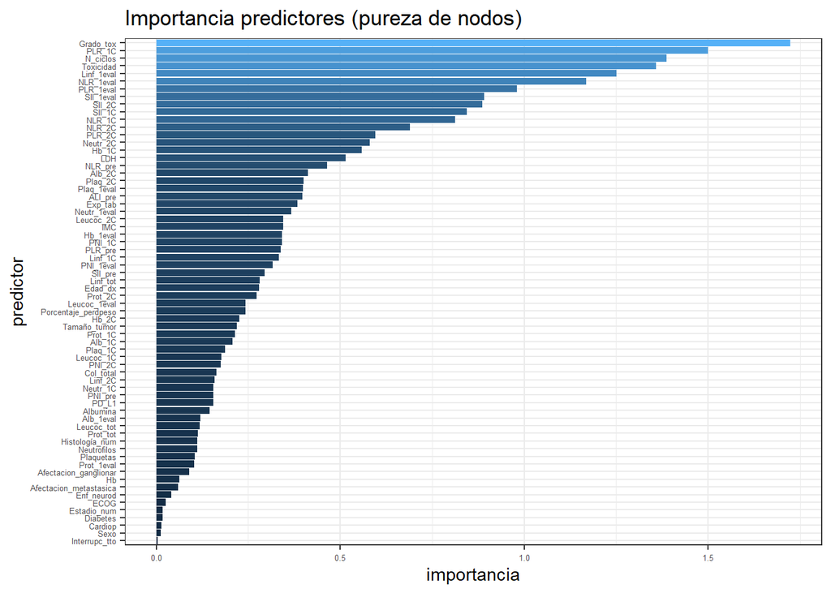

```r
# Entrenamiento modelo
modelo <- rand_forest(
             mode  = "regression"
          ) %>%
          set_engine(
            engine     = "ranger",
            importance = "impurity",
            seed       = 123
          )

modelo <- modelo %>% finalize_model(mejores_hiperpar)
modelo <- modelo %>% fit(mejor_resp_num_ok ~., data = X2)

# Importancia
importancia_pred <- modelo$fit$variable.importance %>%
                    enframe(name = "predictor", value = "importancia")

# Gráfico
ggplot(
  data = importancia_pred,
  aes(x    = reorder(predictor, importancia),
      y    = importancia,
      fill = importancia)
) +
labs(x = "predictor", title = "Importancia predictores (pureza de nodos)") +
geom_col() +
coord_flip() +
theme_bw() +
theme(legend.position = "none", axis.text = element_text(size = 5))
```

## TOP 15

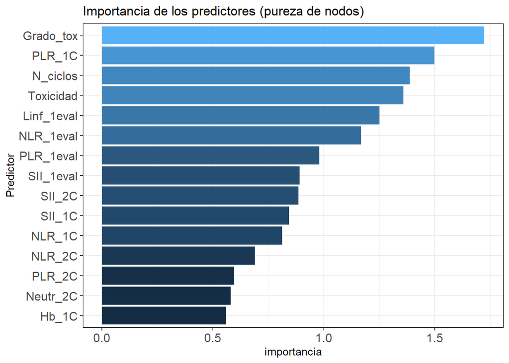

```r
# Filtrar para mantener solo las 15 variables más importantes
importancia_pred_top15 <- importancia_pred %>%
                          arrange(desc(importancia)) %>%
                          top_n(15, importancia)

# Gráfico de las 15 variables más importantes
ggplot(
  data = importancia_pred_top15,
  aes(x    = reorder(predictor, importancia),
      y    = importancia,
      fill = importancia)
) +
labs(x = "Predictor", title = "Importancia de los predictores (pureza de nodos)") +
geom_col() +
coord_flip() +
theme_bw() +
theme(legend.position = "none", axis.text = element_text(size = 12))
```

## Importancia por permutación

Se entrena de nuevo el modelo, con los mejores hiperparámetros encontrados, pero esta vez indicando importance = “permutation”.

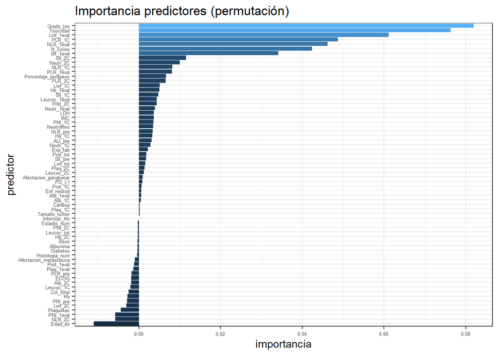

```r
# Entrenamiento modelo
modelo <- rand_forest(
             mode  = "regression"
          ) %>%
          set_engine(
            engine     = "ranger",
            importance = "permutation",
            seed       = 123
          )

modelo <- modelo %>% finalize_model(mejores_hiperpar)
modelo <- modelo %>% fit(mejor_resp_num_ok ~., data = X2)

# Importancia
importancia_pred <- modelo$fit$variable.importance %>%
                    enframe(name = "predictor", value = "importancia")

# Gráfico
ggplot(
  data = importancia_pred,
  aes(x    = reorder(predictor, importancia),
      y    = importancia,
      fill = importancia)
) +
labs(x = "predictor", title = "Importancia predictores (permutación)") +
geom_col() +
coord_flip() +
theme_bw() +
theme(legend.position = "none", axis.text = element_text(size = 5))
```

## Top 15

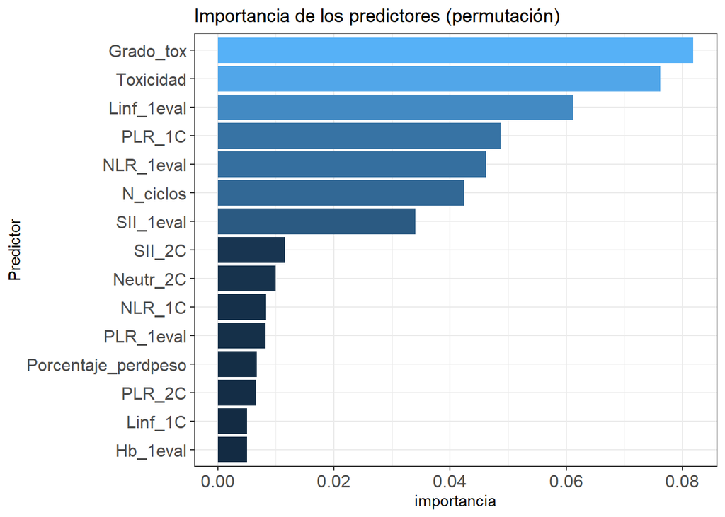

```r
# Filtrar para mantener solo las 15 variables más importantes
importancia_pred_top15 <- importancia_pred %>%
                          arrange(desc(importancia)) %>%
                          slice_max(order_by = importancia, n = 15)  # Usamos slice_max que es más explícito

# Gráfico de las 15 variables más importantes
ggplot(
  data = importancia_pred_top15,
  aes(x    = reorder(predictor, importancia),
      y    = importancia,
      fill = importancia)
) +
labs(x = "Predictor", title = "Importancia de los predictores (permutación)") +
geom_col() +
coord_flip() +
theme_bw() +
theme(legend.position = "none", axis.text = element_text(size = 12))
```

Ambas estrategias identifican Grado_tox, Toxicidad, Linf_1eval, PLR_1C y NLR_1eval, como los predictores más influyentes, acorde a los datos de entrenamiento.

# Clasificación

```r
# Remove all objects from the global environment and the console
rm(list = ls())
cat("\014")
```

## Preparing the data

```r
df <- read_excel("df_definitivo-2.xlsx", sheet = "Copia de datos")
rownames(df) = df$id
df$Afectacion_ganglionar = as.numeric(df$Afectacion_ganglionar)
df$Afectacion_metastasica = as.numeric(df$Afectacion_metastasica)
df$Tamaño_tumor = as.numeric(df$Tamaño_tumor)
df$Grado_tox = as.numeric(df$Grado_tox)
df$SII_pre = log(df$SII_pre)
df$SII_1C = log(df$SII_1C)
df$SII_2C = log(df$SII_2C)
df$SII_1eval = log(df$SII_1eval)

variables_inutiles = c("Anciano", "Peso", "Talla", "SG", "SG_cens", "SLP", "SLP_cens", "Tipo_tox", "NLR2C_corte4o5")

df2 = select(df, -all_of(variables_inutiles))
```

## SELECCIÓN DE VARIABLES PARA MEJOR RESPUESTA

```r
X2 = df2[,2:67]
X2 = data.frame(scale(X2, center = TRUE, scale = TRUE))
X2$mejor_resp_num_ok <- as.factor(df2$mejor_resp_num_ok)
```

## Modelo sin hiperparámetros

```r
# Creación y entrenamiento del modelo
# ==============================================================================
set.seed(123)
modelo_sin_ajustar  <- ranger(
            formula   = mejor_resp_num_ok ~ .,
            data      = X2,
            num.trees = 10,
            seed      = 123
           )

print(modelo_sin_ajustar)
```

```
## Ranger result
##
## Call:
##  ranger(formula = mejor_resp_num_ok ~ ., data = X2, num.trees = 10,      seed = 123)
##
## Type:                             Classification
## Number of trees:                  10
## Sample size:                      34
## Number of independent variables:  66
## Mtry:                             8
## Target node size:                 1
## Variable importance mode:         none
## Splitrule:                        gini
## OOB prediction error:             61.76 %
```

```r
predict(modelo_sin_ajustar, X2) %>% head
```

```
## $predictions
##  [1] 0 0 1 2 2 0 1 1 2 1 3 1 1 2 2 1 1 1 1 0 3 1 1 2 1 3 0 3 1 1 3 1 1 1
## Levels: 0 1 2 3
##
## $num.trees
## [1] 10
##
## $num.independent.variables
## [1] 66
##
## $num.samples
## [1] 34
##
## $treetype
## [1] "Classification"
```

## Ealuating the model

```r
# Training data
p_train <- predict(modelo_sin_ajustar, X2)

# Evaluation data frame (Training)
eval_train <- data.frame(obs=X2$mejor_resp_num_ok,
                         pred=p_train)
head(eval_train)
```

```
##   obs prediction
## 1   0          0
## 2   0          0
## 3   1          1
## 4   2          2
## 5   2          2
## 6   0          0
```

```r
predicciones_ <- p_train$predictions
```

```r
# Predicción usando el modelo
predictions <- predict(modelo_sin_ajustar, X2, type = "response")

# Convertir las predicciones y los valores reales en factores si aún no lo son
predicciones_ <- predictions$predictions

# Crear un marco de datos para evaluación que incluya observaciones y predicciones
eval_train <- data.frame(
  obs = X2$mejor_resp_num_ok,  # las observaciones reales
  pred = as.factor(predicciones_)  # asegúrate de convertir las predicciones a factor
)

# Calcular la matriz de confusión
conf_matrix <- confusionMatrix(eval_train$pred, eval_train$obs)
print(conf_matrix)
```

```
## Confusion Matrix and Statistics
##
##           Reference
## Prediction  0  1  2  3
##          0  5  0  0  0
##          1  0 17  1  0
##          2  0  0  6  0
##          3  0  0  0  5
##
## Overall Statistics
##
##                Accuracy : 0.9706
##                  95% CI : (0.8467, 0.9993)
##     No Information Rate : 0.5
##     P-Value [Acc > NIR] : 2.037e-09
##
##                   Kappa : 0.9551
##
##  Mcnemar's Test P-Value : NA
##
## Statistics by Class:
##
##                      Class: 0 Class: 1 Class: 2 Class: 3
## Sensitivity            1.0000   1.0000   0.8571   1.0000
## Specificity            1.0000   0.9412   1.0000   1.0000
## Pos Pred Value         1.0000   0.9444   1.0000   1.0000
## Neg Pred Value         1.0000   1.0000   0.9643   1.0000
## Prevalence             0.1471   0.5000   0.2059   0.1471
## Detection Rate         0.1471   0.5000   0.1765   0.1471
## Detection Prevalence   0.1471   0.5294   0.1765   0.1471
## Balanced Accuracy      1.0000   0.9706   0.9286   1.0000
```

## Mejora de los hiperparámetros

```r
# DEFINICIÓN DEL MODELO Y DE LOS HIPERPARÁMETROS A OPTIMIZAR
# ==============================================================================
modelo <- rand_forest(
             mode  = "classification",
             mtry  = tune(),
             trees = tune()
          ) %>%
          set_engine(
            engine     = "ranger",
            max.depth  = tune(),
            importance = "none",
            seed       = 123
          )

# DEFINICIÓN DEL PREPROCESADO
# ==============================================================================
# En este caso no hay preprocesado, por lo que el transformer solo contiene
# la definición de la fórmula y los datos de entrenamiento.
transformer <- recipe(
                  formula = mejor_resp_num_ok ~ .,
                  data    =  X2
               )

# DEFINICIÓN DE LA ESTRATEGIA DE VALIDACIÓN Y CREACIÓN DE PARTICIONES
# ==============================================================================
set.seed(1234)
cv_folds <- vfold_cv(
              data    = X2,
              v       = nrow(X2),
              repeats = 1,
              strata  = mejor_resp_num_ok
            )

# WORKFLOW
# ==============================================================================
workflow_modelado <- workflow() %>%
                     add_recipe(transformer) %>%
                     add_model(modelo)


# GRID DE HIPERPARÁMETROS
# ==============================================================================
hiperpar_grid <- expand_grid(
                  'trees'     = c(50, 100, 500, 1000, 5000),
                  'mtry'      = c(3, 5, 7, ncol(X2)-1),
                  'max.depth' = c(1, 3, 10, 20)
                 )

# EJECUCIÓN DE LA OPTIMIZACIÓN DE HIPERPARÁMETROS
# ==============================================================================
cl <- makePSOCKcluster(parallel::detectCores() - 1)
registerDoParallel(cl)

grid_fit <- tune_grid(
              object    = workflow_modelado,
              resamples = cv_folds,
              metrics   = metric_set(f_meas),
              grid      = hiperpar_grid
            )

stopCluster(cl)
```

```r
# Mejores hiperparámetros por validación cruzada
# ==============================================================================
show_best(grid_fit, metric = "f_meas", n = 1)
```

```
## # A tibble: 1 × 9
##    mtry trees max.depth .metric .estimator  mean     n std_err .config
##   <dbl> <dbl>     <dbl> <chr>   <chr>      <dbl> <int>   <dbl> <chr>
## 1     5   500        10 f_meas  macro      0.870    17  0.0530 Preprocessor1_Mo…
```

```r
# ENTRENAMIENTO FINAL
# =============================================================================
mejores_hiperpar <- select_best(grid_fit, metric = "f_meas")

modelo_final_fit <- finalize_workflow(
                        x = workflow_modelado,
                        parameters = mejores_hiperpar
                    ) %>%
                    fit(
                      data = X2
                    ) %>%
                    extract_fit_parsnip()
```

```r
# Error de train del modelo final
# ==============================================================================
predicciones <- modelo_final_fit %>%
                predict(new_data = X2)

predicciones <- predicciones %>%
                bind_cols(X2 %>% dplyr::select(mejor_resp_num_ok))

accuracy_test  <- accuracy(
                     data     = predicciones,
                     truth    = mejor_resp_num_ok,
                     estimate = .pred_class,
                     na_rm    = TRUE
                  )
accuracy_test
```

```
## # A tibble: 1 × 3
##   .metric  .estimator .estimate
##   <chr>    <chr>          <dbl>
## 1 accuracy multiclass         1
```

```r
mat_confusion <- predicciones %>%
                 conf_mat(
                   truth     = mejor_resp_num_ok,
                   estimate  = .pred_class
                 )
mat_confusion
```

```
##           Truth
## Prediction  0  1  2  3
##          0  5  0  0  0
##          1  0 17  0  0
##          2  0  0  7  0
##          3  0  0  0  5
```

## Predicción de probabilidades

La mayoría de implementaciones de Random Forest, entre ellas la de ranger, permiten predecir probabilidades cuando se trata de problemas de clasificación. Es importante entender cómo se calculan estos valores para interpretarlos y utilizarlos correctamente.

```r
# Predicción de probabilidades
# ==============================================================================
predicciones <- modelo_final_fit %>%
                predict(new_data = X2, type = "prob")
head(predicciones, 4)
```

```
## # A tibble: 4 × 4
##   .pred_0 .pred_1 .pred_2 .pred_3
##     <dbl>   <dbl>   <dbl>   <dbl>
## 1  0.497    0.340  0.111   0.0524
## 2  0.492    0.315  0.0923  0.100
## 3  0.0836   0.780  0.104   0.0321
## 4  0.104    0.342  0.520   0.0341
```

Por defecto, predict() asigna cada nueva observación a la clase con mayor probabilidad (en caso de empate se asigna de forma aleatoria). Sin embargo, este no tiene por qué ser el comportamiento deseado en todos los casos.

## Importancia de predictores

Importancia por pureza de nodos

En los modelos anteriores, el argumento importance se deja por defecto como “none”. Esto desactiva el cálculo de importancia de predictores para reducir así el tiempo de entrenamiento. Se entrena de nuevo el modelo, con los mejores hiperparámetros encontrados, pero esta vez indicando importance = “impurity”. Los modelos ranger calculan la impureza a partir del índice Gini en problemas de clasificación y con la varianza en regresión.

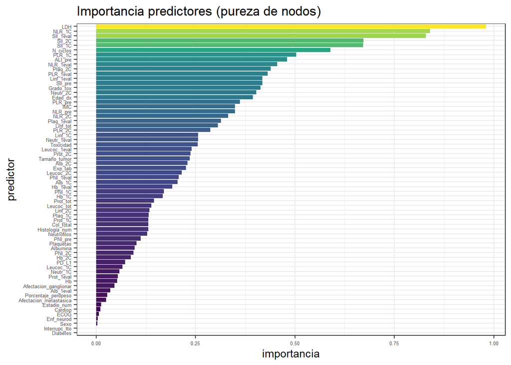

```r
# Entrenamiento modelo
modelo <- rand_forest(
             mode  = "classification"
          ) %>%
          set_engine(
            engine     = "ranger",
            importance = "impurity",
            seed       = 123
          )

modelo <- modelo %>% finalize_model(mejores_hiperpar)
modelo <- modelo %>% fit(mejor_resp_num_ok ~., data = X2)

# Importancia
importancia_pred <- modelo$fit$variable.importance %>%
                    enframe(name = "predictor", value = "importancia")

# Gráfico
ggplot(
  data = importancia_pred,
  aes(x    = reorder(predictor, importancia),
      y    = importancia,
      fill = importancia)
) +
labs(x = "predictor", title = "Importancia predictores (pureza de nodos)") +
geom_col() +
scale_fill_viridis_c() +
coord_flip() +
theme_bw() +
theme(legend.position = "none", axis.text = element_text(size = 5))
```

## TOP 15

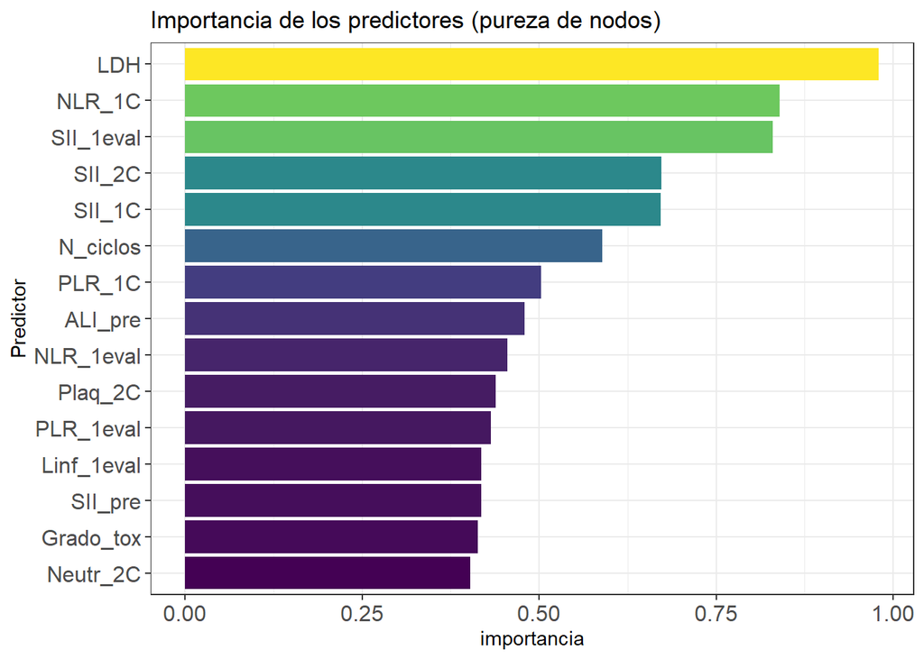

```r
# Filtrar para mantener solo las 15 variables más importantes
importancia_pred_top15 <- importancia_pred %>%
                          arrange(desc(importancia)) %>%
                          top_n(15, importancia)

# Gráfico de las 15 variables más importantes
ggplot(
  data = importancia_pred_top15,
  aes(x    = reorder(predictor, importancia),
      y    = importancia,
      fill = importancia)
) +
labs(x = "Predictor", title = "Importancia de los predictores (pureza de nodos)") +
geom_col() +
scale_fill_viridis_c() +  # Usa un gradiente de color para representar la importancia
coord_flip() +  # Invierte los ejes para mejor visualización de las etiquetas
theme_bw() +
theme(legend.position = "none", axis.text = element_text(size = 12))  # Ajusta el tamaño del texto para mejor legibilidad
```

## Importancia por permutación

Se entrena de nuevo el modelo, con los mejores hiperparámetros encontrados, pero esta vez indicando importance = “permutation”.

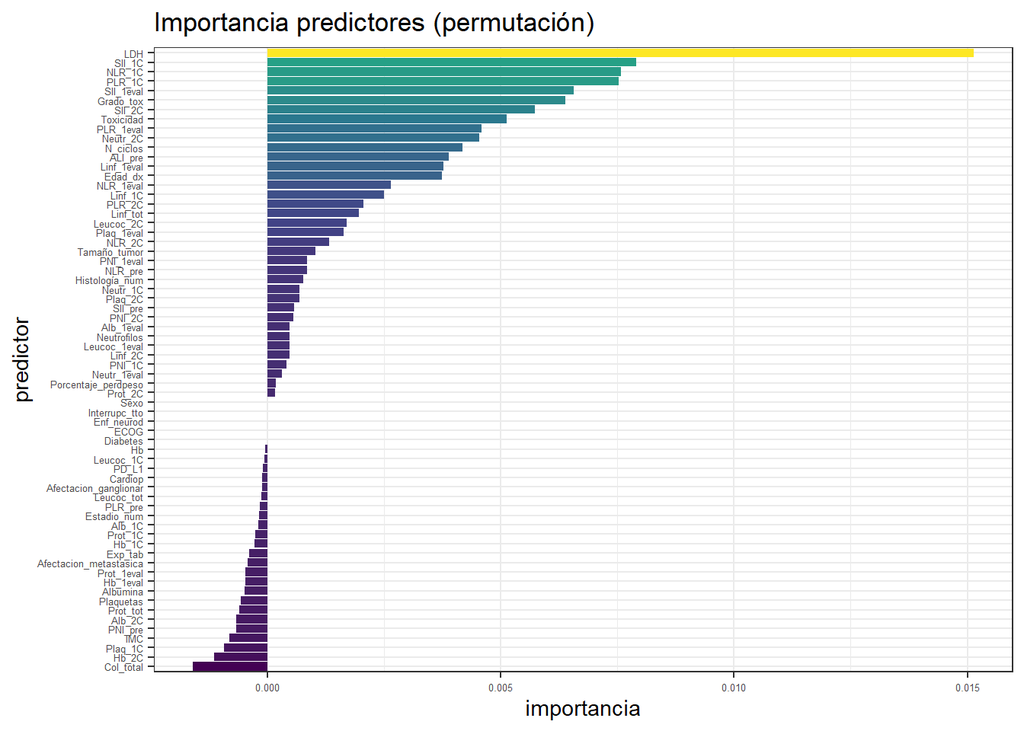

```r
# Entrenamiento modelo
modelo <- rand_forest(
             mode  = "classification"
          ) %>%
          set_engine(
            engine     = "ranger",
            importance = "permutation",
            seed       = 123
          )

modelo <- modelo %>% finalize_model(mejores_hiperpar)
modelo <- modelo %>% fit(mejor_resp_num_ok ~., data = X2)

# Importancia
importancia_pred <- modelo$fit$variable.importance %>%
                    enframe(name = "predictor", value = "importancia")

# Gráfico
ggplot(
  data = importancia_pred,
  aes(x    = reorder(predictor, importancia),
      y    = importancia,
      fill = importancia)
) +
labs(x = "predictor", title = "Importancia predictores (permutación)") +
geom_col() +
scale_fill_viridis_c() +
coord_flip() +
theme_bw() +
theme(legend.position = "none", axis.text = element_text(size = 5))
```

## TOP 15

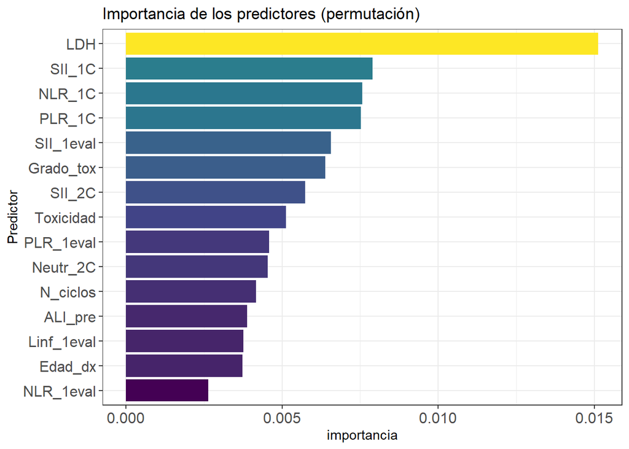

```r
# Filtrar para mantener solo las 15 variables más importantes
importancia_pred_top15 <- importancia_pred %>%
                          arrange(desc(importancia)) %>%
                          top_n(15, importancia)

# Gráfico de las 15 variables más importantes
ggplot(
  data = importancia_pred_top15,
  aes(x    = reorder(predictor, importancia),
      y    = importancia,
      fill = importancia)
) +
labs(x = "Predictor", title = "Importancia de los predictores (permutación)") +
geom_col() +
scale_fill_viridis_c() +  # Utiliza una escala de color para representar la importancia
coord_flip() +  # Invierte los ejes para una mejor visualización de los nombres de los predictores
theme_bw() +  # Utiliza un tema blanco y negro para el gráfico
theme(legend.position = "none", axis.text = element_text(size = 12))  # Ajusta el tamaño del texto para mejorar la legibilidad
```